[figure not shown]

МИНОБРНАУКИ РОССИИ  
Федеральное государственное бюджетное образовательное учреждение высшегообразования  
**“МИРЭА - РОССИЙСКИЙ ТЕХНОЛОГИЧЕСКИЙ УНИВЕРСИТЕТ”**  
Лабораторная работа: “Сбор информации о компаниях”

Выполнил: студент 4 курса  
специальности 10.05.05 группы ББСО-02-16  
Жумаева В.А.  
Проверил:  
Захарчук И.И.

Москва, 2020

### **Цель работы:**

Cобрать информацию о 5 компаниях из списка S&P.

### **Исходные данные:**

1. Ноутбук Lenovo ideapad 330-15AST.  
2. OS Linux.  
3. Nmap - свободная утилита, предназначенная для разнообразного настраиваемого сканирования IP-сетей.

## **Altria Group Inc.**

Altria Group Inc. - американская компания, один из лидеров мирового рынка табачных изделий.

**№**

**Признак**

**Значение**

**1**

Сайт

www.altria.com

**2**

IP-адрес

*165.160.13.20*

**3**

Местонахождение

Richmond, VA 23230-1723, United States

**4**

Телефон

*+1-804-274-2200*

**5**

E-mail

domain.administration@altria.com

**6**

Порты

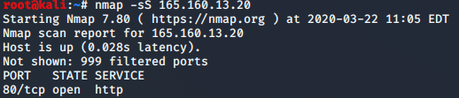

**7**

Хостинг

**8**

Web-технологии

[figure not shown]

## **McDonalds Corporation**

McDonalds Corporation - американская корпорация, работающая в сфере общественного питания.

**№**

**Признак**

**Значение**

**1**

Сайт

[www.mcdonalds.com](https://mcdonalds.com)

**2**

IP-адрес

*52.6.111.61*

**3**

Местонахождение

Ashburn, Virginia 20147, United States

**4**

Телефон

*+1-630-623-7345*

**5**

E-mail

dns.manager@us.mcd.com

**6**

Порты

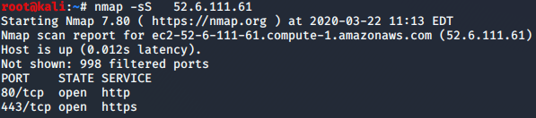

**7**

Хостинг

**8**

Web-технологии

[figure not shown]

## **General Electric Company**

General Electric Company - американская многоотраслевая корпорация, производитель многих видов техники.

**№**

**Признак**

**Значение**

**1**

Сайт

[www.ge.com](https://ge.com)

**2**

IP-адрес

*204.74.99.100*

**3**

Местонахождение

5 Necco Street Boston, MA 02210

**4**

Телефон

*+1-617-443-3000*

**5**

E-mail

domain.admin@ge.com

**6**

Порты

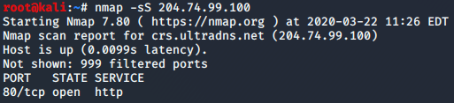

**7**

Хостинг

**8**

Web-технологии

[figure not shown]

## **Honeywell International Inc.**

Honeywell International Inc. - американская корпорация, производящая электронные системы управления и автоматизации.

**№**

**Признак**

**Значение**

**1**

Сайт

[www.honeywell.com](https://www.honeywell.com/)

**2**

IP-адрес

*104.40.48.29*

**3**

Местонахождение

Charlotte, North Carolina, United States

**4**

Телефон

*1-877-841-2840*

**5**

E-mail

detectgas@Honeywell.com

**6**

Порты

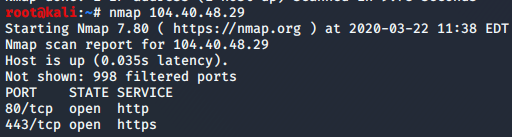

**7**

Хостинг

**8**

Web-технологии

[figure not shown]

## **Medtronic plc**

Medtronic plc - один из крупнейших производителей медицинского оборудования.

**№**

**Признак**

**Значение**

**1**

Сайт

[www.medtronic.com](https://www.medtronic.com/)

**2**

IP-адрес

*144.15.107.150*

**3**

Местонахождение

20 Lower Hatch Street Dublin 2, Ireland

**4**

Телефон

*+1-763-514-4000*

**5**

E-mail

mdt-dreg-tech@medtronic.com

**6**

Порты

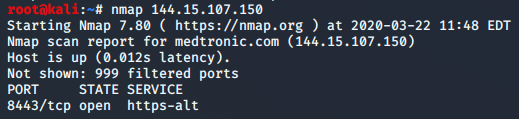

**7**

Хостинг

**8**

Web-технологии

[figure not shown]

**Вывод:** с помощью различных утилит мы собрали информацию о 5 компаниях из списка S&P.